# HW 14: Maps

# wrangle data, create new column and remove columns, pivot_longer to put the years into a single column, group_by state and use summarize(),

```r
lyme_disease_tidy <- lyme_disease_raw %>%
  mutate(`2017` = `2017_Confirmed` + `2017_Probable`) %>%
   select(State: "2016", "2017") %>%
  pivot_longer("2007":"2017", names_to = "year", values_to = "cases")%>%
  group_by(State) %>%
  summarise(mean_cases = mean(cases),
            log_mean = log10(mean_cases),
            .groups = "drop")
```

# Use left_join as you did above to merge the fips data frame

```r
lyme_disease_adj <- left_join(lyme_disease_tidy, fips)
```

# Use left_join again to merge your lyme data to the states_df data

```r
lyme_disease_df <- left_join(states_df, lyme_disease_tidy)
```

# Plot your choropleth map using the same ggplot code for the cancer map, change aes(file = …) for geom_sf, scale approprately, add labels

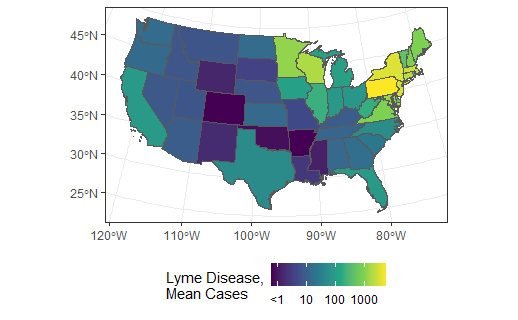

```r
ggplot(lyme_disease_df)+
   geom_sf(aes(fill = log_mean)) +
  scale_fill_viridis_c(name = "Lyme Disease,\nMean Cases",
                       option = "viridis",
                       labels = c("<1", "10", "100", "1000", "5000")) +
  coord_sf(crs = st_crs(5070)) +
  theme_bw() +
  theme(legend.position = "bottom")
```

Map checks out with the notes. Yay!

## Part 3: Dot distribution maps

# load library

```r
library(raster)
library(tidyverse)
library(ggthemes)
library(ggmap)
```

# Global vars ————————————————————-

# Restrict the map to the western US.

```r
min_long <- -126
max_long <- -104
min_lat  <-   31
max_lat  <-   50

set.seed(9618973)
```

# Bigfoot data ————————————————————

```r
bigfoot <- read_csv(here::here("data", "bigfoot.csv"))
bigfoot <- bigfoot %>%
  filter(long >= min_long & long <= max_long,
         lat >= min_lat & lat <= max_lat) %>%
  sample_n(300) %>%
  mutate(name = "Gigantopithecus") %>%
  dplyr::select(name, long, lat)
```

# Bear data ————————————————————–

```r
bears <- read_csv(here::here("data", "bears.csv"))
both_species <- bind_rows(bigfoot, bears)

head(both_species)
```

| name | long | lat |
| --- | --- | --- |
| Gigantopithecus | -123.4490 | 42.39031 |
| Gigantopithecus | -121.9165 | 45.33000 |
| Gigantopithecus | -122.2780 | 40.79740 |
| Gigantopithecus | -122.1667 | 40.75000 |
| Gigantopithecus | -122.4888 | 45.08370 |
| Gigantopithecus | -121.6156 | 40.92911 |

```r
tail(both_species)
```

| name | long | lat |
| --- | --- | --- |
| Ursus americanus | -125.7660 | 49.18350 |
| Ursus americanus | -110.4483 | 44.94100 |
| Ursus americanus | -118.6961 | 34.94750 |
| Ursus americanus | -113.5683 | 34.60667 |
| Ursus americanus | -122.9068 | 43.41780 |
| Ursus americanus | -124.8627 | 49.87958 |

# get a terrain map of data

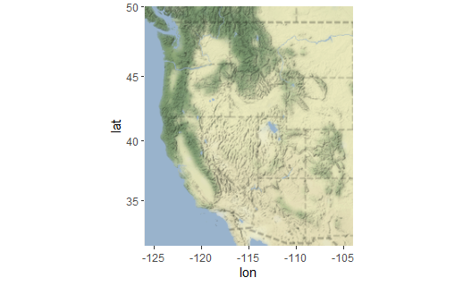

```r
base = get_stamenmap(bbox = c(min_long,
                              min_lat,
                              max_long,
                              max_lat),
                     zoom = 4,
                     maptype = "terrain-background")
ggmap(base)
```

# add plot point layer for big foot

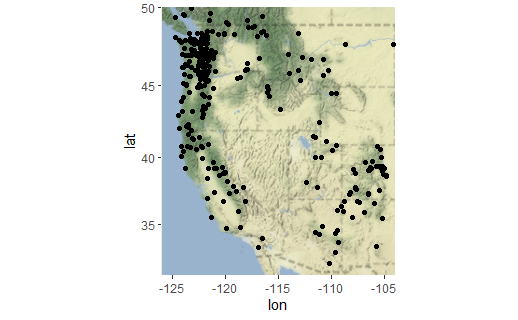

```r
base <- ggmap(base)

base + geom_point(data = bigfoot,
                  aes(x = long,
                      y = lat))
```

# add point layer for black bear

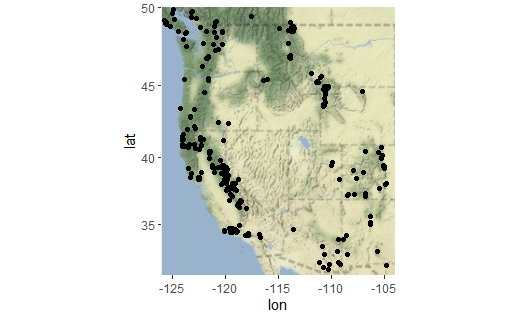

```r
base + geom_point(data = bears,
                  aes(x = long,
                      y = lat))
```

# make a final plot for both species

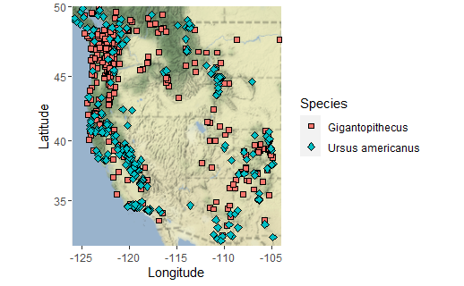

```r
base + geom_point(data = both_species,
                  aes(x = long,
                      y = lat,
                      shape = name,
                      fill = name),
                  size = 2) +
  scale_shape_manual(values = c(22:23)) +
  labs(x = "Longitude",
       y = "Latitude",
       fill = "Species",
       shape = "Species")
```

## make my own distribution map

# change setseed to last 7 digits of SO

```r
min_long <- -126
max_long <- -104
min_lat <-  31
max_lat <- 50

set.seed(1977039)
```

# Bigfoot data

```r
bigfoot <- read_csv(here::here("data", "bigfoot.csv"))
bigfoot <- bigfoot %>%
  filter(long >= min_long & long <= max_long,
         lat >= min_lat & lat <= max_lat) %>%
  sample_n(300) %>%
  mutate(name = "Gigantopithecus") %>%
  dplyr::select(name, long, lat)
```

# Bear data

```r
bears <- read_csv(here::here("data", "bears.csv"))
both_species <- bind_rows(bigfoot, bears)

head(both_species)
```

| name | long | lat |
| --- | --- | --- |
| Gigantopithecus | -105.3792 | 40.17585 |
| Gigantopithecus | -122.7746 | 46.63477 |
| Gigantopithecus | -114.0125 | 45.82285 |
| Gigantopithecus | -119.7853 | 38.33115 |
| Gigantopithecus | -119.7084 | 48.95835 |
| Gigantopithecus | -124.2872 | 48.83319 |

# load and bind data sets

```r
tail(both_species)
```

| name | long | lat |
| --- | --- | --- |
| Ursus americanus | -125.7660 | 49.18350 |
| Ursus americanus | -110.4483 | 44.94100 |
| Ursus americanus | -118.6961 | 34.94750 |
| Ursus americanus | -113.5683 | 34.60667 |
| Ursus americanus | -122.9068 | 43.41780 |
| Ursus americanus | -124.8627 | 49.87958 |

# get terrain map

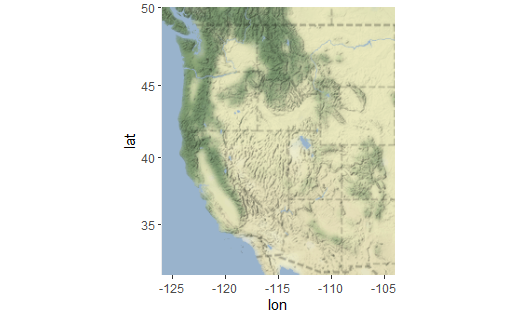

```r
base = get_stamenmap(bbox = c(min_long,
                              min_lat,
                              max_long,
                              max_lat),
                     zoom = 4,
                     maptype = "terrain-background")



ggmap(base)
```

# plot first bigfoot layer on map

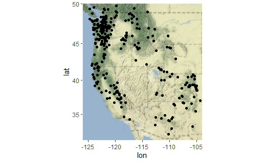

```r
base <- ggmap(base)

base + geom_point(data = bigfoot,
                  aes(x = long,
                      y = lat))
```

# plot bear layer

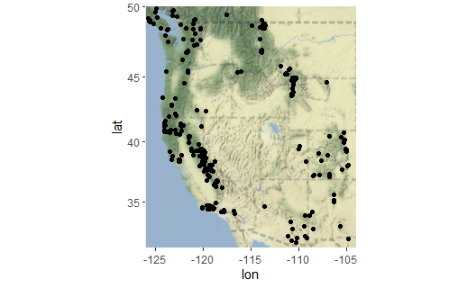

```r
base + geom_point(data = bears,
                  aes(x = long,
                      y = lat))
```

# plot bigfoot compared to black bear

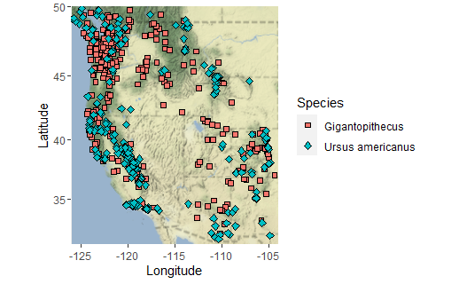

```r
base + geom_point(data = both_species,
                  aes(x = long,
                      y = lat,
                      shape = name,
                      fill = name),
                  size = 2) +
  scale_shape_manual(values = c(22:23)) +
  labs(x = "Longitude",
       y = "Latitude",
       fill = "Species",
       shape = "Species")
```

There seems to be a higher concentration of Gigantopithecus slightly above the state of Nevada. Very similar to the previous graph, just with some minor concentration differences.

## Part 4: Bathymetry

# load libraries

```r
library(tidyverse)
library(marmap)
```

#convert quake depth to feet

```r
min_long <- -170
max_long <- 164
min_lat  <- -42
max_lat  <- -8

earthquakes <- quakes %>%
   mutate(depth = depth * 3280.84)
```

# Will auto read the saved file if present.

```r
fiji <- getNOAA.bathy(lon1 = min_long,
                      lon2 = max_long,
                      lat1 = min_lat,
                      lat2 = max_lat,
                      antimeridian = TRUE,
                      keep = TRUE)
```

```
Querying NOAA database ...
This may take seconds to minutes, depending on grid size
Building bathy matrix ...
```

# Could also just use autoplot() without the .bathy extension.

```
Ignoring unknown parameters: size
```

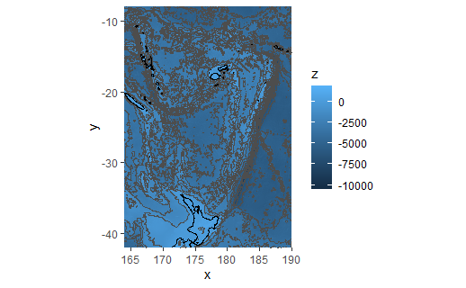

```r
autoplot.bathy(fiji,
         geom = c("raster", "contour"),
         size = 0.1,
         na.rm = TRUE)
```

# Using autoplot, which “knows” to use autoplot.bathy

```
Ignoring unknown parameters: size
```

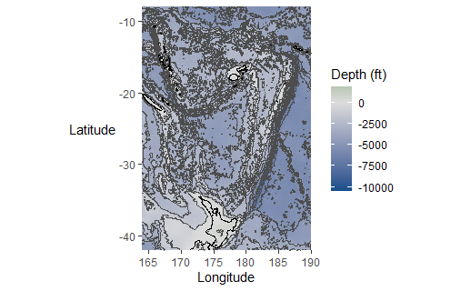

```r
autoplot(fiji,
         geom = c("raster","contour"),
         size = 0.1,
         na.rm = TRUE) +
  scale_fill_gradient2(low = "dodgerblue4",
                       mid = "gainsboro",
                       high = "darkgreen",
                       name = "Depth (ft)") +
  labs(x = "Longitude",
       y = "Latitude") +
  theme(axis.title.y = element_text(angle = 0,
                                    vjust = 0.5))
```

# create base_map

```r
base_map <- autoplot(fiji,
                     geom = c("raster","contour"),
                     size = 0.1,
                     na.rm = TRUE) +
  scale_fill_gradient2(low = "dodgerblue4",
                       mid = "gainsboro",
                       high = "darkgreen",
                       name = "Depth (ft)") +
  labs(x = "Longitude",
       y = "Latitude") +
  theme(axis.title.y = element_text(angle = 0,
                                    vjust = 0.5))
```

```
Ignoring unknown parameters: size
```

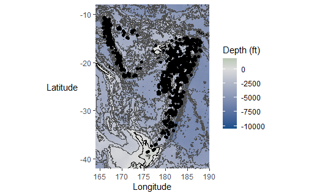

```r
base_map +
  geom_point(data = earthquakes,
             aes(x = long,
                 y = lat))
```

# adjust size to help with crowding

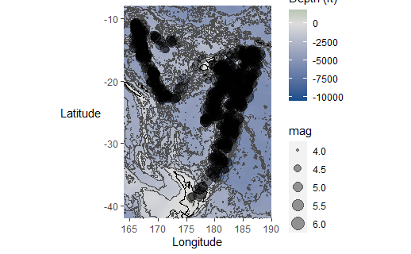

```r
base_map +
  geom_point(data = earthquakes,
             aes(x = long,
                 y = lat,
                 size = mag),
             alpha = 0.4)
```

# set min and max point sizes for magnitude

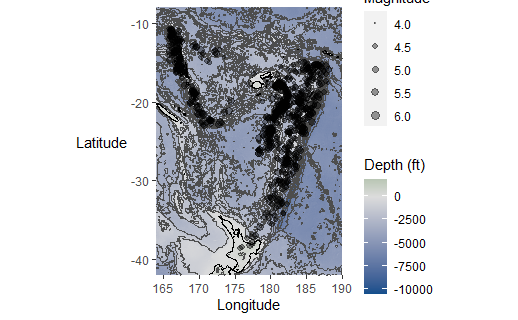

```r
base_map +
  geom_point(data = earthquakes,
             aes(x = long,
                 y = lat,
                 size = mag),
             alpha = 0.4) +
  scale_size_continuous(range = c(0.5,3), name = "Magnitude")
```

## now I try it

#Set new global variables

```r
min_long <- -90
max_long <- -58
min_lat  <- 8
max_lat  <- 25

earthquakes <- quakes %>%
   mutate(depth = depth * 3280.84)
```

# Load blennies.csv into a blennies object.

```r
blennies <- read_csv(here::here("Data", "blennies.csv"))
```

#Use getNOAA.bathy() function,Set antimeridian to FALSE,Set keep = TRUE,Save the results to a carib_sea object.

```r
carib_sea <- getNOAA.bathy(lon1 = min_long,
                      lon2 = max_long,
                      lat1 = min_lat,
                      lat2 = max_lat,
                      antimeridian = FALSE,
                      keep = TRUE)
```

```
Querying NOAA database ...
This may take seconds to minutes, depending on grid size
Building bathy matrix ...
```

#Use autoplot to plot the base bathymetric map

```r
base_map_2 <- autoplot(carib_sea,
         geom = c("raster","contour"),
         size = 0.1,
         na.rm = TRUE) +
  scale_fill_etopo(guide = FALSE) +
  labs(x = "Longitude",
       y = "Latitude") +
  theme(axis.title.y = element_text(angle = 0,
                                    vjust = 0.5))
```

```
Ignoring unknown parameters: size
```

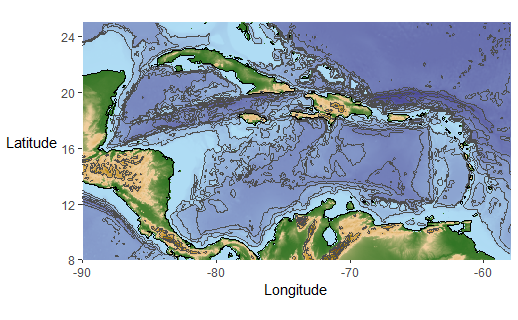

```r
base_map_2
```

#Add the blennies

[figure not shown]

```r
base_map_2 +
  geom_point(data = blennies,
             aes(x = long,
                 y = lat, shape = name),color = "red", size = 2.8)+
  labs(shape = "Species")+
  theme(legend.position = "bottom")+
  theme(legend.text = element_text(face = "italic"))
```

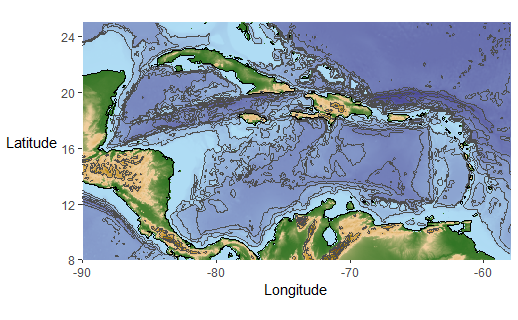

```r
base_map_2
```

I really enjoyed this one. It’s neat to be able to import data and see it represented on graphs with terrain.